# Visualize: Layers, Exploratory Data Analysis, Communication

Module 04

Ray J. Hoobler

# Layers (ggplot2)

## Asthetic mapping

What can be included in the arguments of the `aes()` function?

```
ggplot(data = <DATA>) +
  <GEOM_FUNCTION>(
     mapping = aes(<MAPPINGS>)
  )
```

Variables (quantitative or categorical) can be mapped to the following aesthetics:

- x
- y
- color
- fill
- size
- shape
- linetype
- alpha

## Explore Aesthetics with the Palmer Penguins Data (1/6)

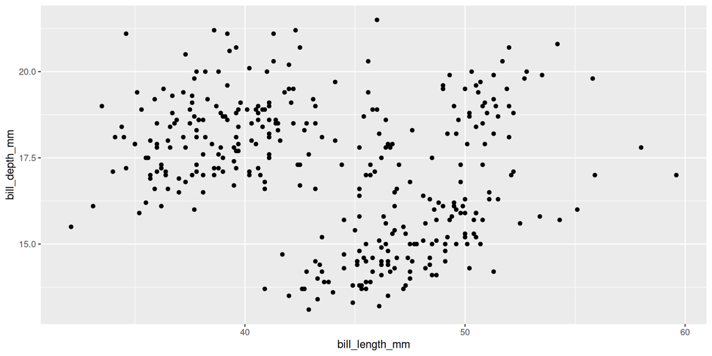

```r
library(palmerpenguins)
library(tidyverse)

ggplot(data = penguins) +
  geom_point(mapping = aes(x = bill_length_mm, y = bill_depth_mm))
```

## Explore Aesthetics with the Palmer Penguins Data (2/6)

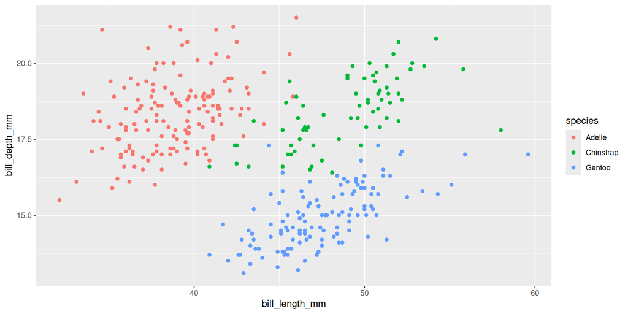

```r
ggplot(data = penguins) +
  geom_point(mapping = aes(x = bill_length_mm, y = bill_depth_mm,
                           color = species))
```

## Explore Aesthetics with the Palmer Penguins Data (3/6)

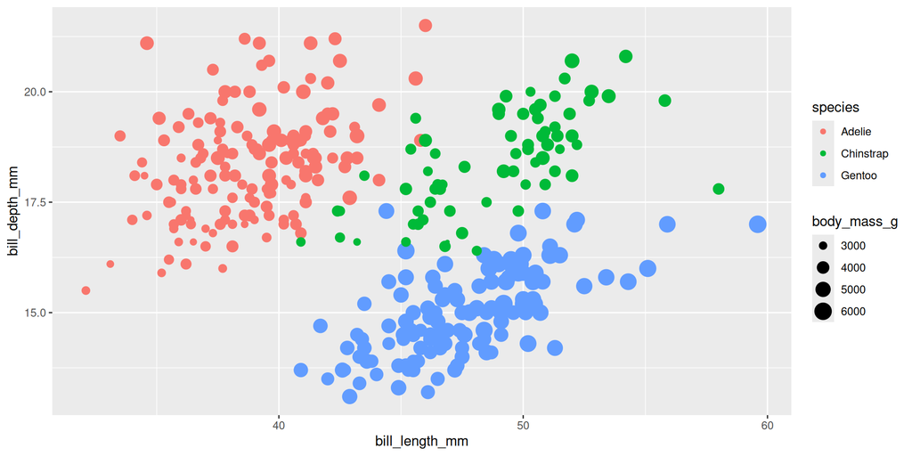

```r
ggplot(data = penguins) +
  geom_point(mapping = aes(x = bill_length_mm, y = bill_depth_mm,
                           color = species,
                           size = body_mass_g))
```

## Explore Aesthetics with the Palmer Penguins Data (4/6)

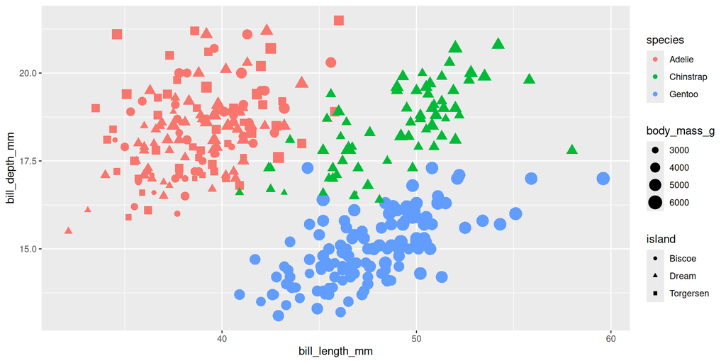

```r
ggplot(data = penguins) +
  geom_point(mapping = aes(x = bill_length_mm, y = bill_depth_mm,
                           color = species,
                           size = body_mass_g,
                           shape=island))
```

## Explore Aesthetics with the Palmer Penguins Data (5/6)

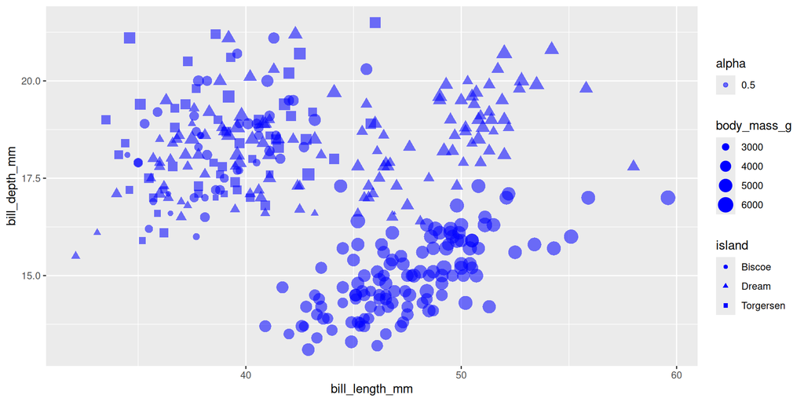

```r
ggplot(data = penguins) +
  geom_point(mapping = aes(x = bill_length_mm, y = bill_depth_mm,
                           size = body_mass_g,
                           shape=island,
                           alpha = 0.5),
             color = "blue")
```

## Explore Aesthetics with the Palmer Penguins Data (6/6)

What’s happening here?

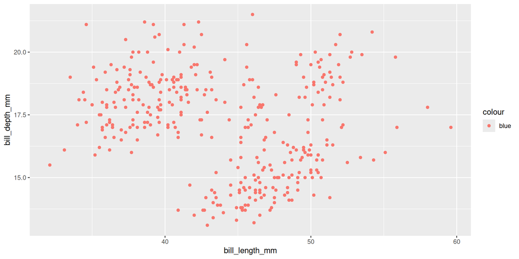

```r
ggplot(data = penguins) +
  geom_point(mapping = aes(x = bill_length_mm, y = bill_depth_mm,
                           color = "blue"))
```

## Geometric Objects (1/2)

### ggplot2 provides more than 40 geoms!

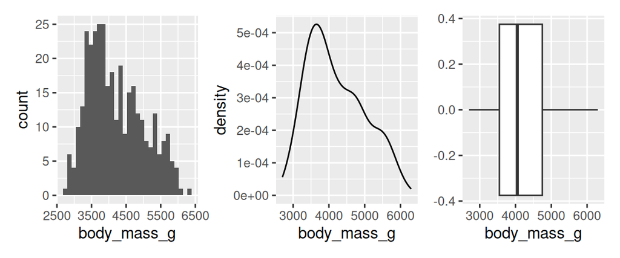

```r
library(patchwork)

p1 <- ggplot(penguins, aes(x = body_mass_g)) +
  geom_histogram()

p2 <- ggplot(penguins, aes(x =body_mass_g)) +
  geom_density()

p3 <- ggplot(penguins, aes(x = body_mass_g)) +
  geom_boxplot()

p1 + p2 + p3
```

## Geometric Objects (2/2)

### Libraries are availabe for specialty plots (i.e., “pair plots”)

```r
library(GGally)

ggpairs(penguins, columns = 3:6, (aes(color = species, alpha = 1/4)))
```

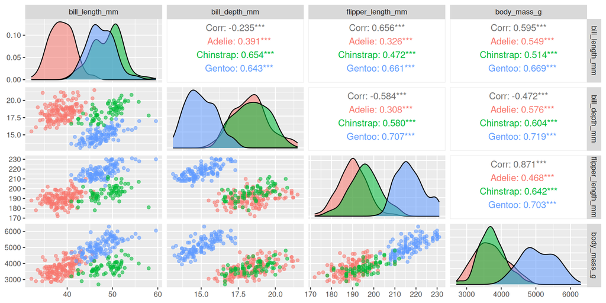

## Facets

The pair plot above is an example of a facet plot. We can create a facet plot by adding the `facet_wrap()` or `facet_grid()` function to the ggplot object.

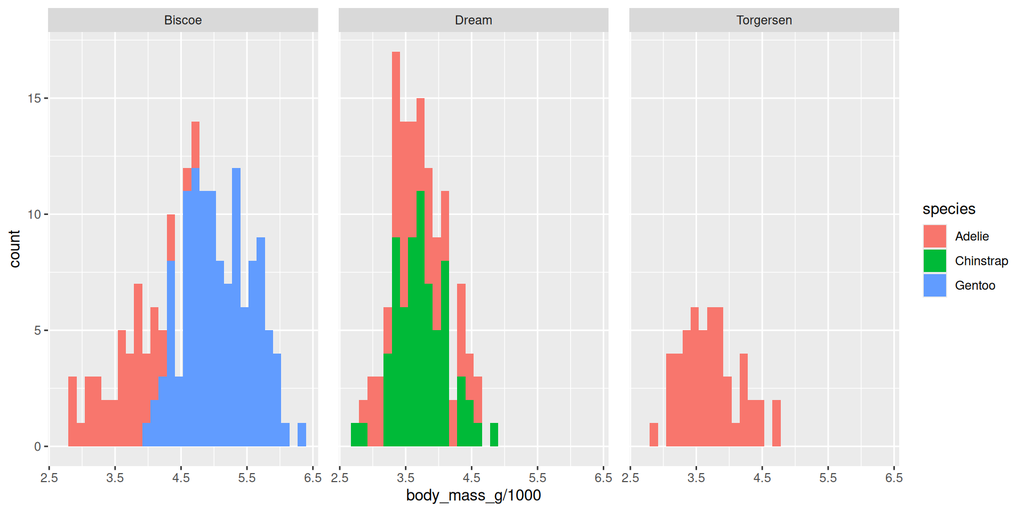

```r
penguins |>
  ggplot() +
  geom_histogram(aes(x = body_mass_g/1000, fill = species), bins = 30) +
  facet_wrap(vars(island), ) +
  theme(panel.spacing.x = unit(1, "lines"))
```

## `facet_grid()` (1/3)

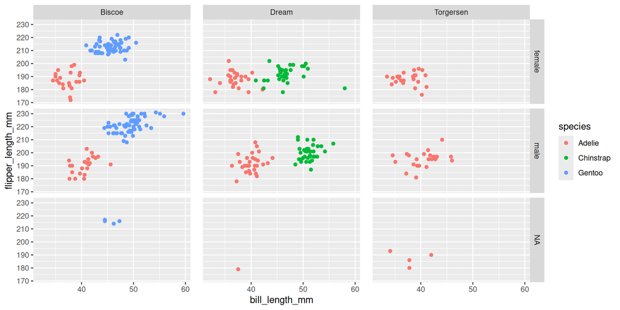

```r
penguins |>
  ggplot() +
  geom_point(aes(x = bill_length_mm, y = flipper_length_mm, color=species)) +
  facet_grid(vars(sex), vars(island)) +
  theme(panel.spacing.x = unit(1, "lines"))
```

## `facet_grid()` (1/3)

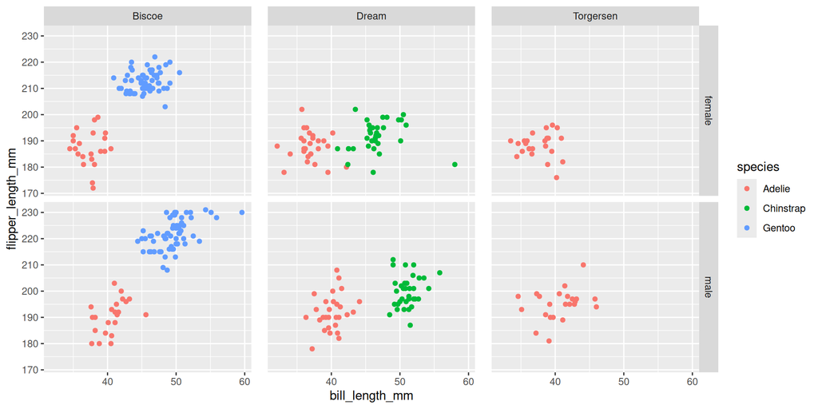

```r
penguins |>
  filter(!is.na(sex)) |>
  ggplot() +
  geom_point(aes(x = bill_length_mm, y = flipper_length_mm, color=species)) +
  facet_grid(vars(sex), vars(island)) +
  theme(panel.spacing.x = unit(1, "lines"))
```

## `facet_grid()` (3/3)

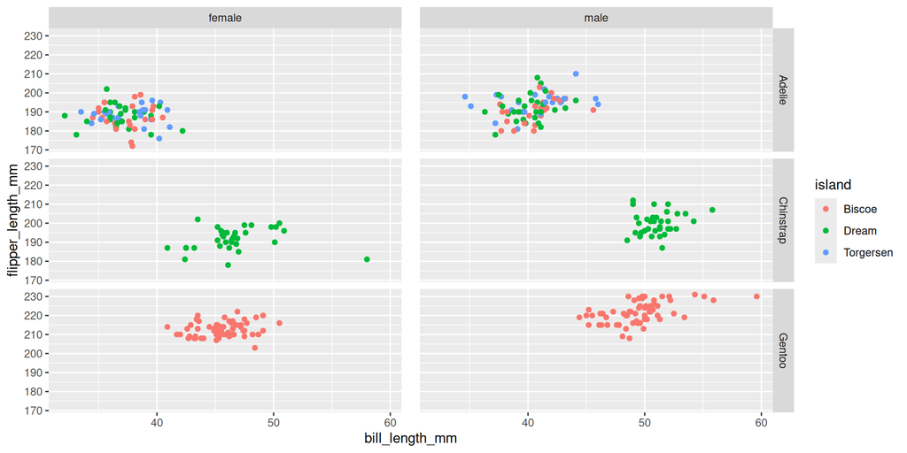

```r
penguins |>
  filter(!is.na(sex)) |>
  ggplot() +
  geom_point(aes(x = bill_length_mm, y = flipper_length_mm, color=island)) +
  facet_grid(vars(species), vars(sex)) +
  theme(panel.spacing.x = unit(1, "lines"))
```

## Facets using the `~` operator

Using the `~` operator to specify the rows and columns of the facet grid.

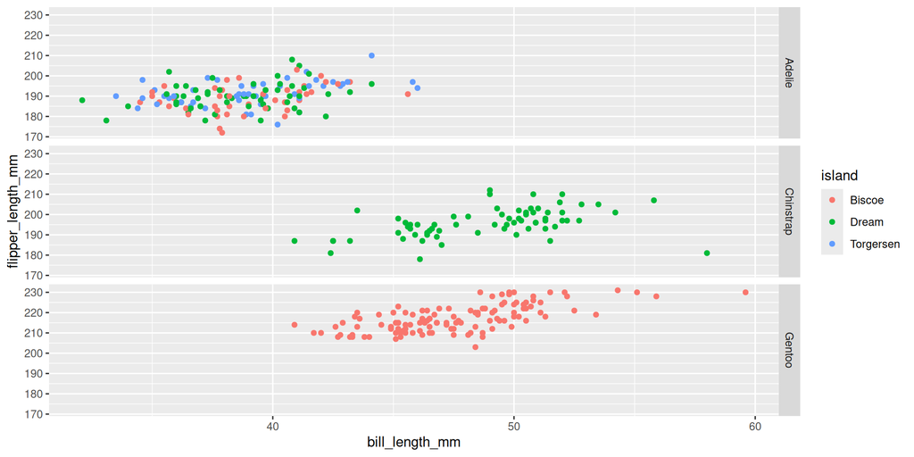

```r
penguins |>
  filter(!is.na(sex)) |>
  ggplot() +
  geom_point(aes(x = bill_length_mm, y = flipper_length_mm, color=island)) +
  facet_grid(species ~ .) +
  theme(panel.spacing.x = unit(1, "lines"))
```

## Using the Dot(.) in ggplot2 Faceting

### Prompt for Claude

Can you explain the use of “.” in R? Specifically, as it’s used in ggplot2 for functions like facet_grid(. ~ species)

### Response from Claude

The dot (.) in R, especially as used in ggplot2 functions like `facet_grid()`, has a special meaning. Let me explain its use:

1. In ggplot2’s `facet_grid()`:

   In the context of `facet_grid(. ~ species)`, the dot serves as a placeholder. It indicates that you don’t want to split the plot on the rows (left side of the tilde ~), but you do want to split it on the columns (right side of the tilde) based on the “species” variable.
   - `facet_grid(. ~ species)`: Creates separate plots for each unique value in the “species” column, arranged horizontally.
   - `facet_grid(species ~ .)`: Would create separate plots for each unique value in the “species” column, arranged vertically.
   - `facet_grid(var1 ~ var2)`: Would create a grid of plots, with “var1” determining the rows and “var2” the columns.
2. In other R contexts:

   The dot can also be used in other situations in R:
   - In pipe operations (`%>%` or `|>`), the dot represents the object being passed through the pipe.
   - In formulas, it can represent “all other variables” not explicitly mentioned.
   - In function definitions, it can be used to pass additional arguments.

## Assignment

Chapter 9 9.4.1 Exercises. Questions 1 through 7

Chapter 9 9.3.1 Exercises, questions 1 through 4

## Statistical Transformations (1/2)

Several geometric objects in ggplot2 carry out statistical transformations, examples include:

- `geom_histogram()` calculates the count of observations in bins.
- `geom_density()` calculates the density of a variable.
- `geom_bar()` calculates the count of observations for each level of a categorical variable.
- `geom_boxplot()` calculates the median, quartiles, and outliers of a variable.
- `geom_smooth()` calculates a smoothed line (or fit) through the data.

## Statistical Transformations (2/2)

For every geometric object `geom_*`, there is a corresponding statistical transformation `stat_*`.

Additional transformations can be called to override the default values. For instance, the `geom_histogram()` includes the following:

#### Computed variables

These are calculated by the ‘stat’ part of layers and can be accessed with delayed evaluation.

- after_stat(count)  
  number of points in bin.
- **after_stat(density)**  
  density of points in bin, scaled to integrate to 1.
- after_stat(ncount)  
  count, scaled to a maximum of 1.
- after_stat(ndensity)  
  density, scaled to a maximum of 1.
- after_stat(width)  
  widths of bins.

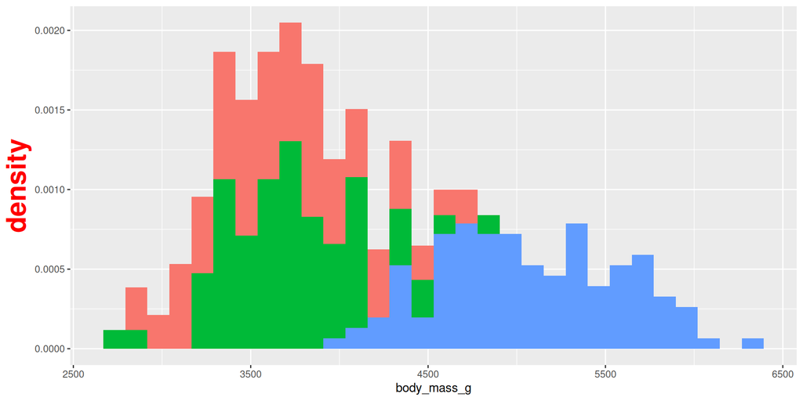

```r
penguins |>
  ggplot() +
  geom_histogram(aes(x = body_mass_g, y = after_stat(density), fill = species),
                 bins = 30, show.legend = FALSE) +
  theme(
    axis.title.y = element_text(size = 24, color = "red", face = "bold")
  )
```

## Position Adjustments (1/6)

```r
machine <- read_table("datasets/MACHINE.DAT",
                      skip = 25,
                      col_names = c("machine", "day", "time", "sample", "diameter"),
                      col_types = "ffffd")

machine
```

| machine | day | time | sample | diameter |
| --- | --- | --- | --- | --- |
| 1 | 1 | 1 | 1 | 0.1247 |
| 1 | 1 | 1 | 2 | 0.1264 |
| 1 | 1 | 1 | 3 | 0.1252 |
| 1 | 1 | 1 | 4 | 0.1253 |
| 1 | 1 | 1 | 5 | 0.1263 |
| 1 | 1 | 1 | 6 | 0.1251 |
| 1 | 1 | 1 | 7 | 0.1254 |
| 1 | 1 | 1 | 8 | 0.1239 |
| 1 | 1 | 1 | 9 | 0.1235 |
| 1 | 1 | 1 | 10 | 0.1257 |

[output cut: 170 more lines]

## Position Adjustments (2/6)

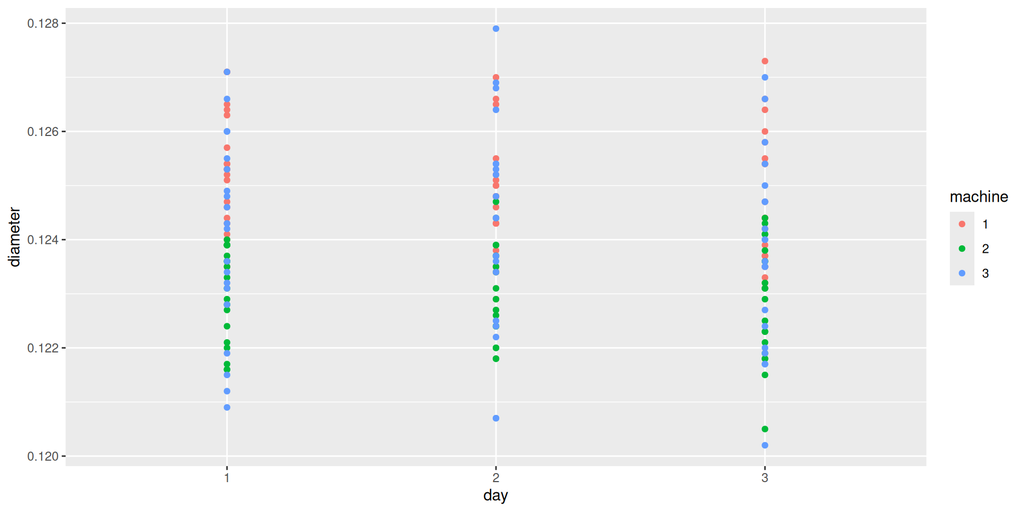

```r
machine |>
  ggplot() +
  geom_point(aes(x = day, y = diameter,
                 color = machine))
```

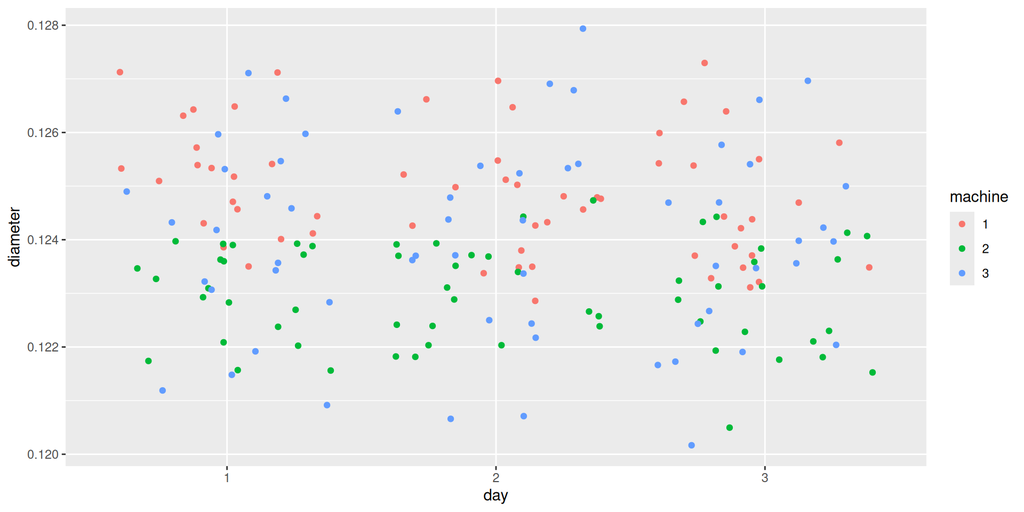

```r
machine |>
  ggplot() +
  geom_point(aes(x = day, y = diameter,
                 color = machine), position = "jitter")
```

## Position Adjustments (3/6)

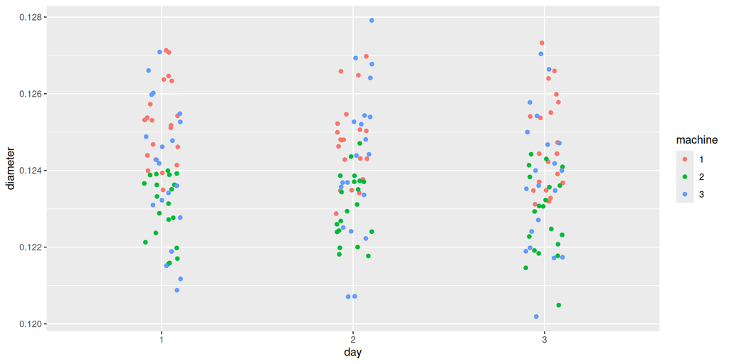

```r
machine |>
  ggplot() +
  geom_point(aes(x = day, y = diameter, color = machine),
             position = position_jitter(width = 0.1))
```

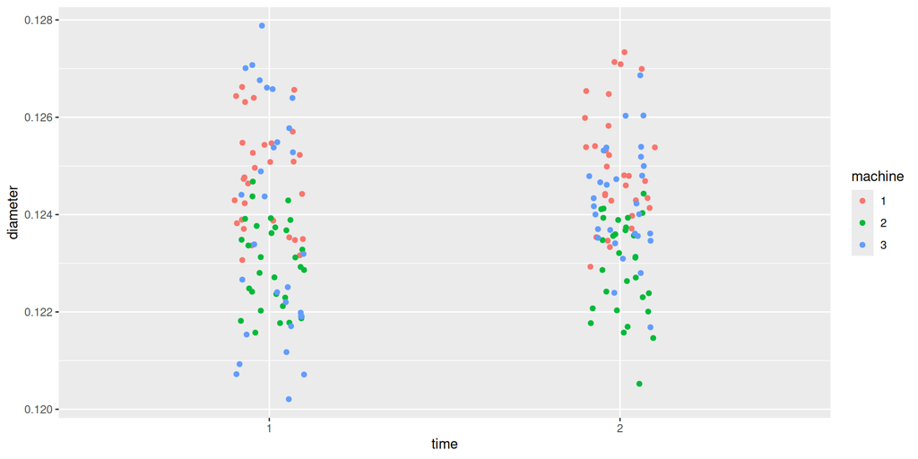

```r
machine |>
  ggplot() +
  geom_point(aes(x = time, y = diameter, color = machine),
             position = position_jitter(width = 0.1))
```

## Position Adjustments (4/6)

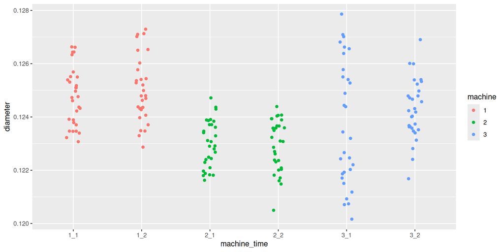

```r
machine |>
  mutate(machine_time = str_c(machine, time, sep = "_")) |>
  ggplot() +
  geom_point(aes(x = machine_time, y = diameter, color=machine), position = position_jitter(width = 0.1))
```

## Position Adjustments (5/6)

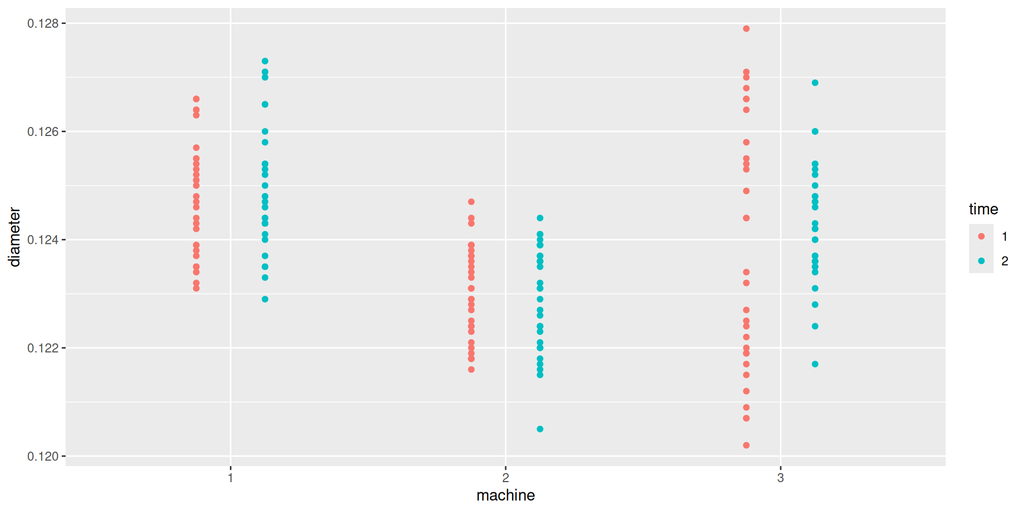

```r
machine |>
  ggplot() +
  geom_point(aes(x = machine, y = diameter, color = time), position = position_dodge(width = 0.5))
```

## Position Adjustments (6/6)

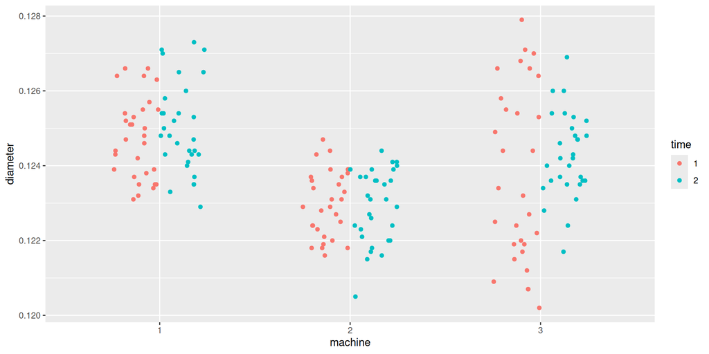

```r
machine |>
  ggplot() +
  geom_point(aes(x = machine, y = diameter, color = time), position = position_jitterdodge(dodge.width = 0.5, jitter.width = 0.5))
```

## The Layered Grammar of Graphics

````markdown
```{r}
ggplot(data = <DATA>) +
  <GEOM_FUNCTION>(
     mapping = aes(<MAPPINGS>),
     stat = <STAT>,
     position = <POSITION>
  ) +
  <COORDINATE_FUNCTION> +
  <FACET_FUNCTION>
```
````

# Exploratory Data Analysis (EDA)

## EDA with the MACHINE.DAT Data (1/3)

Location **AND** Variation

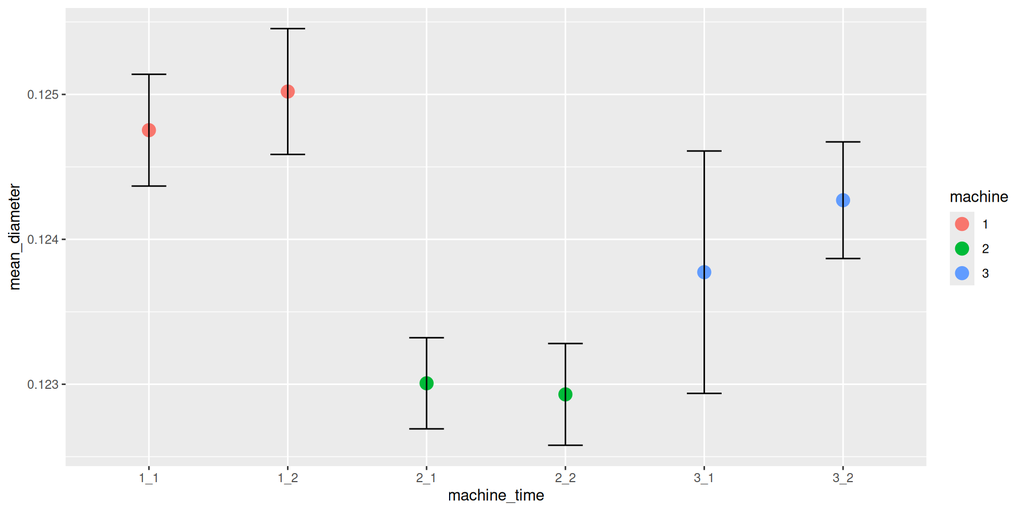

```r
machine |>
  group_by(machine, time) |>
  summarise(mean_diameter = mean(diameter),
            sd_diameter = sd(diameter),
            ci_diameter = 1.96 * sd(diameter) / sqrt(n())) |>
  ungroup() |>
  mutate(machine_time = str_c(machine, time, sep = "_")) |>
  ggplot() +
  geom_point(aes(x = machine_time, y = mean_diameter, color = machine), size = 4) +
  geom_errorbar(aes(x = machine_time,
                    ymin = mean_diameter - ci_diameter,
                    ymax = mean_diameter + ci_diameter), width = 0.25)
```

## EDA with the MACHINE.DAT data (2/3)

Location **AND** Variation

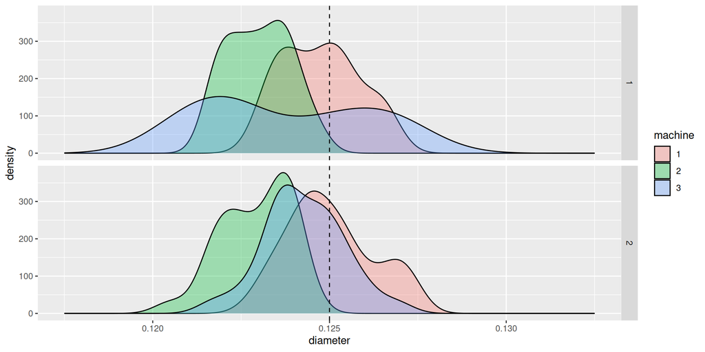

```r
machine |>
  ggplot() +
  geom_density(aes(x = diameter, fill = machine), alpha=1/3) +
  geom_vline(xintercept = 0.125, linetype = "dashed") +
  scale_x_continuous(limits = c(0.1175, 0.1325)) +
  facet_grid(rows = vars(time))
```

## EDA with the MACHINE.DAT data (3/3)

Location **AND** Variation

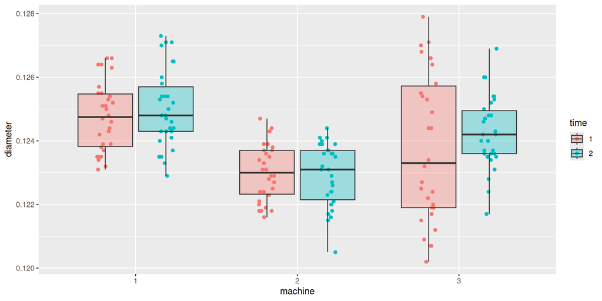

```r
machine |>
  ggplot() +
  geom_point(aes(x = machine, y = diameter, color = time), width = 0.1, position = position_jitterdodge(dodge.width = .75, jitter.width = 0.2)) +
  geom_boxplot(aes(x = machine, y = diameter, fill = time), alpha = 1/3)
```

## Assignment

- Carry out an EDA on the [FURNACE.DAT dataset](https://www.itl.nist.gov/div898/handbook/datasets/FURNACE.DAT).
- Are there any trends in the data that would be difficult to detect with standard summary statistics?
- Are there any outliers in the data? (A description of the experiment is available on the [NIST website](https://www.itl.nist.gov/div898/handbook/ppc/section5/ppc511.htm))

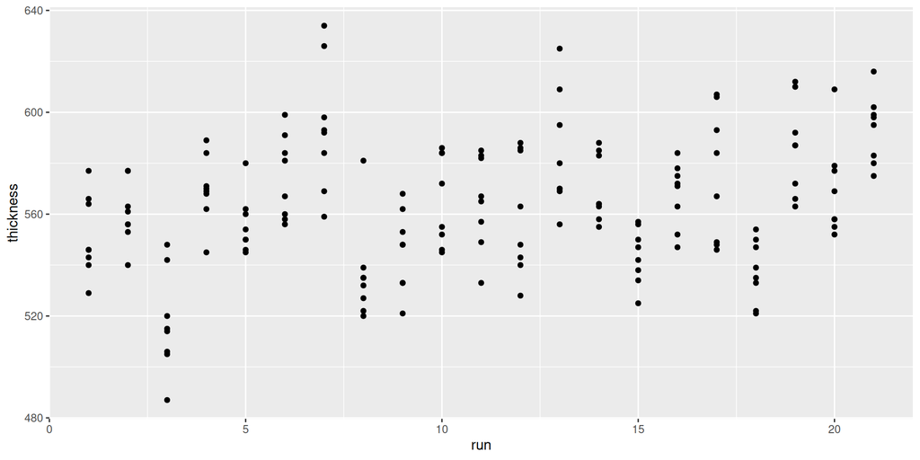

```r
column_names <- c("RUN ZONE WAFER THICKNESS") |>
  str_to_lower() |>
  str_split(" ") |>
  unlist()

furnace <- read_table("datasets/FURNACE.DAT",
                      skip = 25,
                      col_names = column_names,
                      col_types = "iffd")

furnace |>
  ggplot() +
  geom_point(aes(x = run, y = thickness))
```

# Communication

## Labels

For most plots, the `labs()` layer will provide the right amount of customization.

[figure not shown]

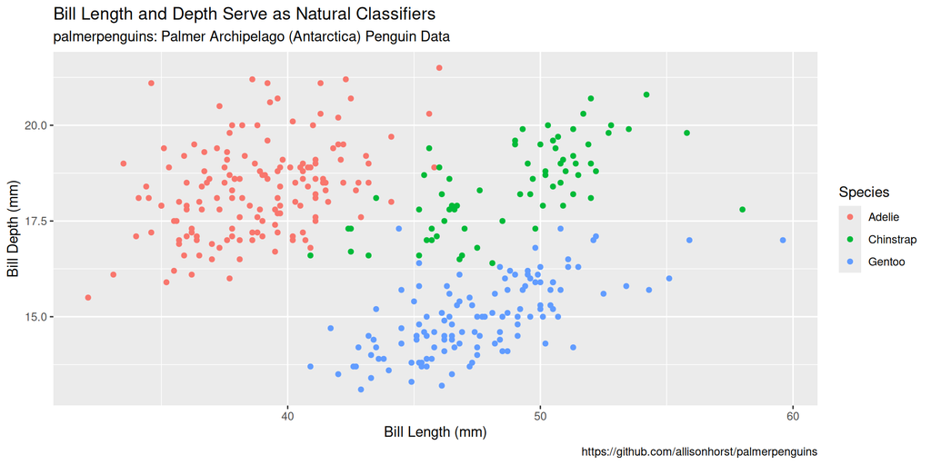

```r
penguins |>
  ggplot() +
  geom_point(aes(x = bill_length_mm, y = bill_depth_mm, color = species)) +
  labs(title = "Bill Length and Depth Serve as Natural Classifiers",
       subtitle = "palmerpenguins: Palmer Archipelago (Antarctica) Penguin Data",
       x = "Bill Length (mm)",
       y = "Bill Depth (mm)",
       color = "Species",
       caption = "https://github.com/allisonhorst/palmerpenguins")
```

## Annotations

- `geom_text()`
- `annotate()`

## Annotations: `geom_text()` (1/2)

### Calculate mean values for Bill Depth and Bill Length for each species

```r
mean_bill_depth_length <- penguins |>
  group_by(species) |>
  summarise(mean_bill_length = mean(bill_length_mm, na.rm = TRUE),
            mean_bill_depth = mean(bill_depth_mm, na.rm = TRUE)) |>
  ungroup()

mean_bill_depth_length
```

| species | mean_bill_length | mean_bill_depth |
| --- | --- | --- |
| Adelie | 38.79139 | 18.34636 |
| Chinstrap | 48.83382 | 18.42059 |
| Gentoo | 47.50488 | 14.98211 |

## Annotations: `geom_text()` (2/2)

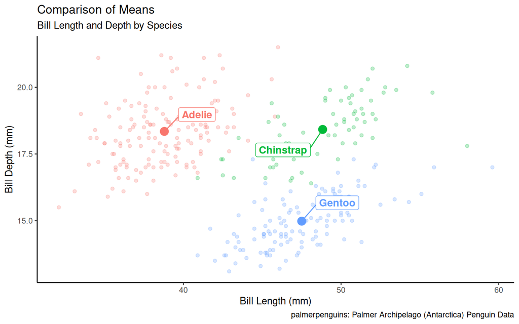

```r
library(ggrepel)

penguins |>
  ggplot() +
  geom_point(aes(x = bill_length_mm, y = bill_depth_mm, color = species), alpha = 1/4, show.legend = FALSE) +
  geom_point(data = mean_bill_depth_length,
             aes(x = mean_bill_length, y = mean_bill_depth, color = species),
             size = 4, show.legend = FALSE) +
  geom_label_repel(data = mean_bill_depth_length,
            aes(x = mean_bill_length, y = mean_bill_depth, label = species, color = species),
            size = 4, fontface = "bold", box.padding = 1, show.legend = FALSE, seed = 42) +
  labs(
    title = "Comparison of Means",
    subtitle = "Bill Length and Depth by Species",
    x = "Bill Length (mm)",
    y = "Bill Depth (mm)",
    caption = "palmerpenguins: Palmer Archipelago (Antarctica) Penguin Data"
  ) +
  theme_classic()
```

## Annotations: `annotate()`

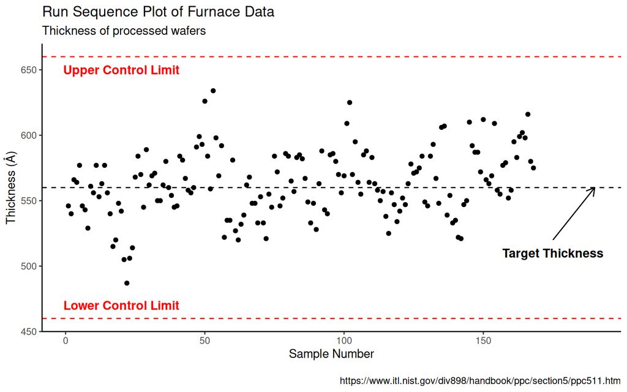

```r
furnace |>
  ggplot() +
  geom_point(aes(x = seq_along(thickness), y = thickness)) +
  geom_hline(yintercept = 560, linetype = "dashed") +
  geom_hline(yintercept = c(460, 660), linetype = "dashed", color = "red") +
  annotate("text", x = 175, y = 560-50, label = "Target Thickness", color = "black", size = 4, fontface = "bold") +
  annotate("segment", x = 175, xend = 190, y = 520, yend = 560,
           arrow = arrow(ends = "last", length = unit(0.3, "cm")),
           size = 0.5, color = "black") +
  annotate("text", x = 20, y = 460+10, label = "Lower Control Limit", color = "red", size = 4, fontface = "bold") +
  annotate("text", x = 20, y = 660-10, label = "Upper Control Limit", color = "red", size = 4, fontface = "bold") +
  labs(
    title = "Run Sequence Plot of Furnace Data",
    subtitle = "Thickness of processed wafers",
    x = "Sample Number",
    y = "Thickness (Å)",
    caption = "\nhttps://www.itl.nist.gov/div898/handbook/ppc/section5/ppc511.htm"
  ) +
  theme_classic()
```

## Scales (1/4)

[FRED Economic Data](https://fred.stlouisfed.org/series/MEHOINUSA672N)

**Source:** [U.S. Census Bureau](http://www.census.gov/)

**Release:** [Income and Poverty in the United States](http://www.census.gov/topics/income-poverty/income.html)

**Units:** 2022 CPI-U-RS Adjusted Dollars, Not Seasonally Adjusted

**Frequency:** Annual

Household data are collected as of March.

> . . . the Consumer Price Index retroactive series using current methods (R-CPI-U-RS) presents an estimate of the CPI for all Urban Consumers (CPI-U) from 1978 to the present that incorporates, when possible, most of the improvements made over that time span into the entire series.

```r
rmhi <- read_csv("datasets/MEHOINUSA672N.csv", col_names = TRUE) |>
  rename(date = DATE, median_income = MEHOINUSA672N)
rmhi |> head()
```

| date | median_income |
| --- | --- |
| 1984-01-01 | 56780 |
| 1985-01-01 | 57860 |
| 1986-01-01 | 60010 |
| 1987-01-01 | 60760 |
| 1988-01-01 | 61210 |
| 1989-01-01 | 62260 |

## Scales (2/4)

### Plot the data

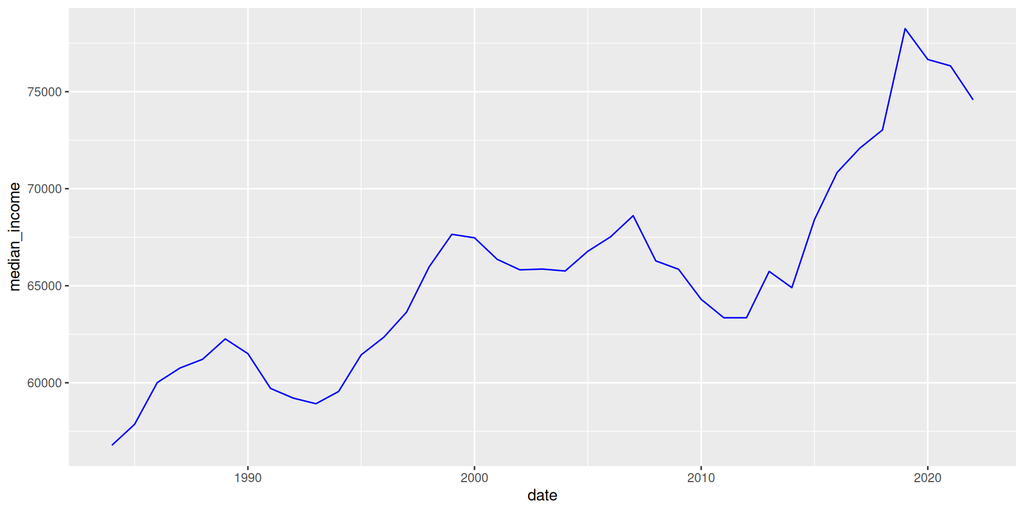

```r
rmhi |>
  ggplot() +
  geom_line(aes(x = date, y = median_income), color = "blue")
```

## Scale (3/4)

### Add labels

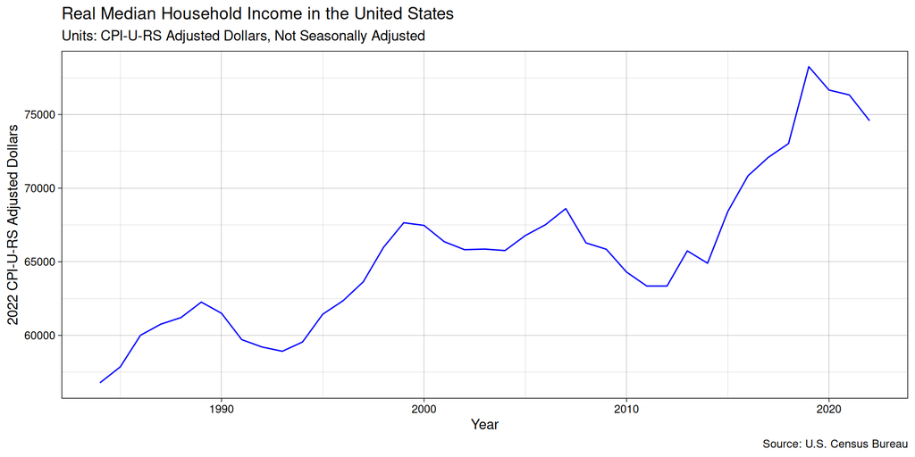

```r
rmhi |>
  ggplot() +
  geom_line(aes(x = date, y = median_income), color = "blue") +
  labs(
    title = "Real Median Household Income in the United States",
    subtitle = "Units: CPI-U-RS Adjusted Dollars, Not Seasonally Adjusted",
    x = "Year",
    y = "2022 CPI-U-RS Adjusted Dollars",
    caption = "Source: U.S. Census Bureau"
  ) +
  theme_linedraw()
```

### What else?

- Update the y-axis to include commas (or dollar symbols).
- Set the x-axis and y-axis limits to provide starting and ending points.
- Customize x-axis and y-axis break points (tick marks).
- Customize various fonts as needed.